# Working Dates, Time Series, and Forecasting

Module 11

Ray J. Hoobler

## Libraries

```r
library(tidyverse)
library(lubridate)
library(fpp3) # Forecasting: Principles and Practice aligned with Tidyverse
```

## Resource for Working with Dates

Chapter 17

## Resources for Time Series Models

[NIST/SEMATECH e-Handbook of Statistical Methods](https://www.itl.nist.gov/div898/handbook/)

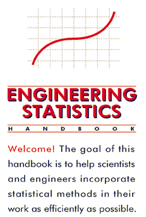

Ch 6.4 Time Series Models

[Forecasting: Principles and Practice](https://otexts.com/fpp3/)

[figure not shown]

# Dates

## Dates in R

Current standard for working with dates: **ISO8601**

## Historical approaches to date handling in R (with help from Claude.ai)

1. Date class (introduced in R 1.0.0)

The original Date class stored dates as number of days since 1970-01-01

```r
date_old <- as.Date("2024-01-01")
print(as.numeric(date_old))  # Days since epoch
```

```
[1] 19723
```

2. POSIXct format (Pre-ISO 8601 standard)

Stored as seconds since 1970-01-01

```r
old_date_ct <- as.POSIXct("2024-01-01 12:00:00")
print(as.numeric(old_date_ct))  # Seconds since epoch
```

```
[1] 1704135600
```

3. POSIXlt format (list-based representation)

```r
old_date_lt <- as.POSIXlt("2024-01-01 12:00:00")
str(unclass(old_date_lt))  # Shows internal structure
```

```
List of 11
 $ sec   : num 0
 $ min   : int 0
 $ hour  : int 12
 $ mday  : int 1
 $ mon   : int 0
 $ year  : int 124
 $ wday  : int 1
 $ yday  : int 0
 $ isdst : int 0
 $ zone  : chr "MST"
 $ gmtoff: int NA
 - attr(*, "tzone")= chr [1:3] "" "MST" "MDT"
 - attr(*, "balanced")= logi TRUE
```

## Common historical date formats and parsing methods

```r
dates <- c(
    "01/02/03",           # Ambiguous MM/DD/YY
    "01-02-2003",         # DD-MM-YYYY or MM-DD-YYYY
    "January 2, 2003",    # Month name format
    "2003.01.02"          # Period-separated
)
```

## Historical parsing approaches

`strptime()` - Traditional parsing method

```r
strptime(dates[1], "%m/%d/%y")
```

```
[1] "2003-01-02 MST"
```

```r
strptime(dates[2], "%d-%m-%Y")
```

```
[1] "2003-02-01 MST"
```

```r
strptime(dates[3], "%B %d, %Y")
```

```
[1] "2003-01-02 MST"
```

`as.Date()` with format specification

```r
as.Date(dates[1], format="%m/%d/%y")
```

```
[1] "2003-01-02"
```

```r
as.Date(dates[2], format="%d-%m-%Y")
```

```
[1] "2003-02-01"
```

## Handling different locales (pre-standardization)

```r
Sys.setlocale("LC_TIME", "C")  # POSIX locale
```

```
[1] "C"
```

```r
format(as.Date("2024-01-01"), "%a %b %d %Y")
```

```
[1] "Mon Jan 01 2024"
```

```r
Sys.setlocale("LC_TIME", "en_US.UTF-8")  # US locale
```

```
[1] "en_US.UTF-8"
```

```r
format(as.Date("2024-01-01"), "%a %b %d %Y")
```

```
[1] "Mon Jan 01 2024"
```

## Historical challenges with time zones

Pre-ISO 8601, timezone handling was less standardized

```r
ct_ny <- as.POSIXct("2024-01-01 12:00:00", tz="America/New_York")
ct_utc <- as.POSIXct("2024-01-01 12:00:00", tz="UTC")
print(difftime(ct_ny, ct_utc))
```

```
Time difference of 5 hours
```

## Demonstrating historical ambiguity issues

```r
ambiguous_date <- "03/04/05"
```

Could be interpreted multiple ways:

```r
as.Date(ambiguous_date, format="%m/%d/%y")  # US interpretation
```

```
[1] "2005-03-04"
```

```r
as.Date(ambiguous_date, format="%d/%m/%y")  # European interpretation
```

```
[1] "2005-04-03"
```

```r
as.Date(ambiguous_date, format="%y/%m/%d")  # ISO-like interpretation
```

```
[1] "2003-04-05"
```

## Modern date handling in R (with help from Claude.ai)

The current ISO 8601 standard in R offers several key advantages:

1. Unambiguous Format:
   - Uses YYYY-MM-DD as the base format
   - Eliminates confusion between US and European date formats
   - Supports both date and time with timezone information
2. Key Features:
   - Hierarchical ordering (largest to smallest units)
   - Optional time components with T separator
   - Standardized timezone offsets
   - Support for weeks and ordinal dates
3. Main Benefits:
   - Machine-readable
   - Sorts correctly as text
   - Internationally recognized
   - Reduces parsing errors
4. Best Practices:
   - Store dates in UTC
   - Use local timezones only for display
   - Always include timezone information for datetime values
   - Use the lubridate package for easier handling

## Reading Dates in the Tidyverse

Here, the date is still being read as a character string.

```r
# A simple data frame with dates
dates_df <- tibble(
    date = c("2024-01-01", "2024-02-01", "2024-03-01"),
    value = c(1, 2, 3)
)

dates_df
```

| date | value |
| --- | --- |
| 2024-01-01 | 1 |
| 2024-02-01 | 2 |
| 2024-03-01 | 3 |

## Reading Dates from a CSV File

The `read_csv()` function from the `readr` package will automatically parse dates.

```r
dates_df |>
  write_csv("datasets/dates.csv")

read_csv("datasets/dates.csv")
```

| date | value |
| --- | --- |
| 2024-01-01 | 1 |
| 2024-02-01 | 2 |
| 2024-03-01 | 3 |

## Coercing Dates in the Tidyverse

We can use the `lubridate` package to coerce the date column to a date object.

```r
dates_df2 <- dates_df |>
  mutate(date = as_date(date)) # as_date() is part of the lubridate package

dates_df2
```

| date | value |
| --- | --- |
| 2024-01-01 | 1 |
| 2024-02-01 | 2 |
| 2024-03-01 | 3 |

## `ggplot2` Recogizes Dates

We can then format them as needed.

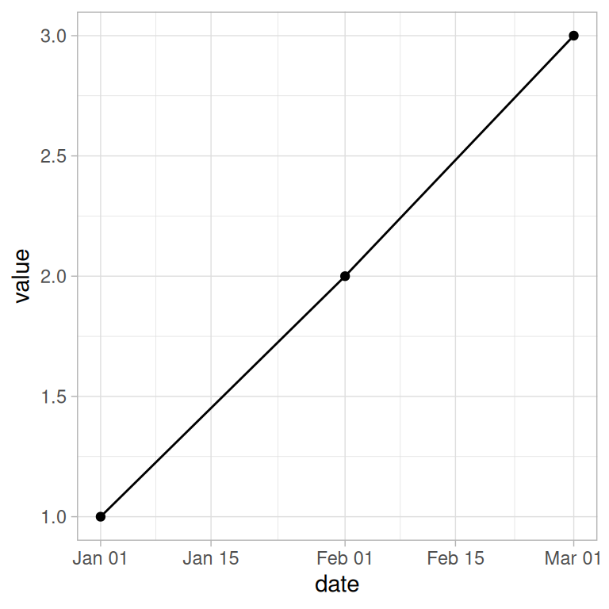

```r
dates_df2 |>
  ggplot(aes(x = date, y = value)) +
  geom_line() +
  geom_point() +
  theme_light()
```

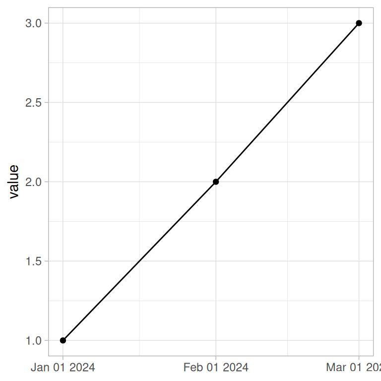

```r
dates_df2 |>
  ggplot(aes(x = date, y = value)) +
  geom_line() +
  geom_point() +
  scale_x_date(
    date_labels = ("%b %d %Y"),
    breaks = dates_df2$date) +
  labs(
    x = NULL
  ) +
  theme_light()
```

# What is a Time Series?

## Definition of Time Series

An ordered sequence of values of a variable at equally spaced time intervals.

**From fpp3**:

Examples of time series data include:

```
Annual Google profits
Quarterly sales results for Amazon
Monthly rainfall
Weekly retail sales
Daily IBM stock prices
Hourly electricity demand
5-minute freeway traffic counts
Time-stamped stock transaction data
```

Anything that is observed sequentially over time is a time series.

## `ts()` data structure (1/2)

### Univariate Time Series

```r
str(co2)
```

```
 Time-Series [1:468] from 1959 to 1998: 315 316 316 318 318 ...
```

```r
co2
```

```
        Jan    Feb    Mar    Apr    May    Jun    Jul    Aug    Sep    Oct
1959 315.42 316.31 316.50 317.56 318.13 318.00 316.39 314.65 313.68 313.18
1960 316.27 316.81 317.42 318.87 319.87 319.43 318.01 315.74 314.00 313.68
1961 316.73 317.54 318.38 319.31 320.42 319.61 318.42 316.63 314.83 315.16
1962 317.78 318.40 319.53 320.42 320.85 320.45 319.45 317.25 316.11 315.27
1963 318.58 318.92 319.70 321.22 322.08 321.31 319.58 317.61 316.05 315.83
1964 319.41 320.07 320.74 321.40 322.06 321.73 320.27 318.54 316.54 316.71
1965 319.27 320.28 320.73 321.97 322.00 321.71 321.05 318.71 317.66 317.14
1966 320.46 321.43 322.23 323.54 323.91 323.59 322.24 320.20 318.48 317.94
1967 322.17 322.34 322.88 324.25 324.83 323.93 322.38 320.76 319.10 319.24
1968 322.40 322.99 323.73 324.86 325.40 325.20 323.98 321.95 320.18 320.09
1969 323.83 324.26 325.47 326.50 327.21 326.54 325.72 323.50 322.22 321.62
1970 324.89 325.82 326.77 327.97 327.91 327.50 326.18 324.53 322.93 322.90
1971 326.01 326.51 327.01 327.62 328.76 328.40 327.20 325.27 323.20 323.40
1972 326.60 327.47 327.58 329.56 329.90 328.92 327.88 326.16 324.68 325.04
```

[output cut: 65 more lines]

## `ts()` data structure (2/2)

### Multivariate Time Series

```r
str(DAAG::greatLakes)
```

```
 Time-Series [1:92, 1:4] from 1918 to 2009: 174 174 174 174 174 ...
 - attr(*, "dimnames")=List of 2
  ..$ : NULL
  ..$ : chr [1:4] "Erie" "michHuron" "Ontario" "StClair"
```

```r
DAAG::greatLakes
```

```
Time Series:
Start = 1918
End = 2009
Frequency = 1
         Erie michHuron  Ontario  StClair
1918 174.0150  176.8867 74.87250 174.9567
1919 174.1808  176.7450 74.95583 175.0767
1920 173.9083  176.6250 74.56750 174.8150
1921 174.0258  176.4883 74.66583 174.8692
1922 173.9275  176.4450 74.65667 174.8108
1923 173.7575  176.2642 74.44333 174.6525
1924 173.8433  176.1867 74.55750 174.6375
1925 173.5933  175.9192 74.39000 174.4058
1926 173.6408  175.8850 74.40250 174.4017
1927 173.8183  176.1483 74.60667 174.5983
```

[output cut: 82 more lines]

# Analyzing Time Series Data: Moving Averages

## Moving Averages (1/8)

```r
supplier <- read_table(
  "Supplier     Cost    Error   ErrorSquared
1   9   -1  1
2   8   -2  4
3   9   -1  1
4   12  2   4
5   9   -1  1
6   12  2   4
7   11  1   1
8   7   -3  9
9   13  3   9
10  9   -1  1
11  11  1   1
12  10  0   0 ", col_names = TRUE
)

supplier
```

| Supplier | Cost | Error | ErrorSquared |
| --- | --- | --- | --- |
| 1 | 9 | -1 | 1 |
| 2 | 8 | -2 | 4 |
| 3 | 9 | -1 | 1 |
| 4 | 12 | 2 | 4 |
| 5 | 9 | -1 | 1 |
| 6 | 12 | 2 | 4 |
| 7 | 11 | 1 | 1 |
| 8 | 7 | -3 | 9 |
| 9 | 13 | 3 | 9 |
| 10 | 9 | -1 | 1 |

[output cut: 2 more lines]

The **mean** cost is: 10.  
The **SSE** is: 36.  
The **MSE** is: 3.

Is the *mean* a good estimate of the cost?

## Moving Averages (2/8)

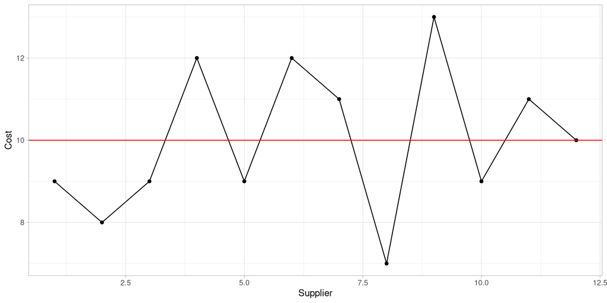

```r
supplier |>
  ggplot(aes(x = Supplier, y = Cost)) +
  geom_line() +
  geom_point() +
  geom_hline(yintercept = mean(supplier$Cost), color = "red") +
  theme_light()
```

## Moving Averages (3/8)

```r
pc_ebt <- read_table(
  "Year     Earnings_M  Mean    Error   Squared_Error
1985    46.163  48.676  -2.513  6.313
1986    46.998  48.676  -1.678  2.814
1987    47.816  48.676  -0.860  0.739
1988    48.311  48.676  -0.365  0.133
1989    48.758  48.676  0.082   0.007
1990    49.164  48.676  0.488   0.239
1991    49.548  48.676  0.872   0.761
1992    48.915  48.676  0.239   0.057
1993    50.315  48.676  1.639   2.688
1994    50.768  48.676  2.092   4.378", col_names = TRUE
)

pc_ebt
```

| Year | Earnings_M | Mean | Error | Squared_Error |
| --- | --- | --- | --- | --- |
| 1985 | 46.163 | 48.676 | -2.513 | 6.313 |
| 1986 | 46.998 | 48.676 | -1.678 | 2.814 |
| 1987 | 47.816 | 48.676 | -0.860 | 0.739 |
| 1988 | 48.311 | 48.676 | -0.365 | 0.133 |
| 1989 | 48.758 | 48.676 | 0.082 | 0.007 |
| 1990 | 49.164 | 48.676 | 0.488 | 0.239 |
| 1991 | 49.548 | 48.676 | 0.872 | 0.761 |
| 1992 | 48.915 | 48.676 | 0.239 | 0.057 |
| 1993 | 50.315 | 48.676 | 1.639 | 2.688 |
| 1994 | 50.768 | 48.676 | 2.092 | 4.378 |

The **mean** Earnings ($M) is: 48.68.  
The **SSE** is: 18.129.  
The **MSE** is: 1.81.

Is the *mean* a good estimate of the Earnings?

## Moving Averages (4/8)

### Plot of earnings over tiem

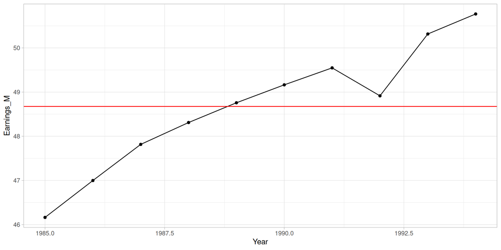

```r
pc_ebt |>
  ggplot(aes(x = Year, y = Earnings_M)) +
  geom_line() +
  geom_point() +
  geom_hline(yintercept = mean(pc_ebt$Earnings_M), color = "red") +
  theme_light()
```

## Moving Averages (5/8)

```r
quarterly_sales <- read_table(
  "Year     Quarter     Period     Sales
90     1      1     362
90     2      2     385
90     3      3     432
90     4      4     341
91     1      5     382
91     2      6     409
91     3      7     498
91     4      8     387
92     1      9     473
92     2     10     513
92     3     11     582
92     4     12     474
93     1     13     544
93     2     14     582
93     3     15     681
93     4     16     557
94     1     17     628
94     2     18     707
94     3     19     773
94     4     20     592
95     1     21     627
95     2     22     725
95     3     23     854
95     4     24     661", col_names = TRUE
)

quarterly_sales
```

| Year | Quarter | Period | Sales |
| --- | --- | --- | --- |
| 90 | 1 | 1 | 362 |
| 90 | 2 | 2 | 385 |
| 90 | 3 | 3 | 432 |
| 90 | 4 | 4 | 341 |
| 91 | 1 | 5 | 382 |
| 91 | 2 | 6 | 409 |
| 91 | 3 | 7 | 498 |
| 91 | 4 | 8 | 387 |
| 92 | 1 | 9 | 473 |
| 92 | 2 | 10 | 513 |

[output cut: 14 more lines]

## Moving Averages (6/8)

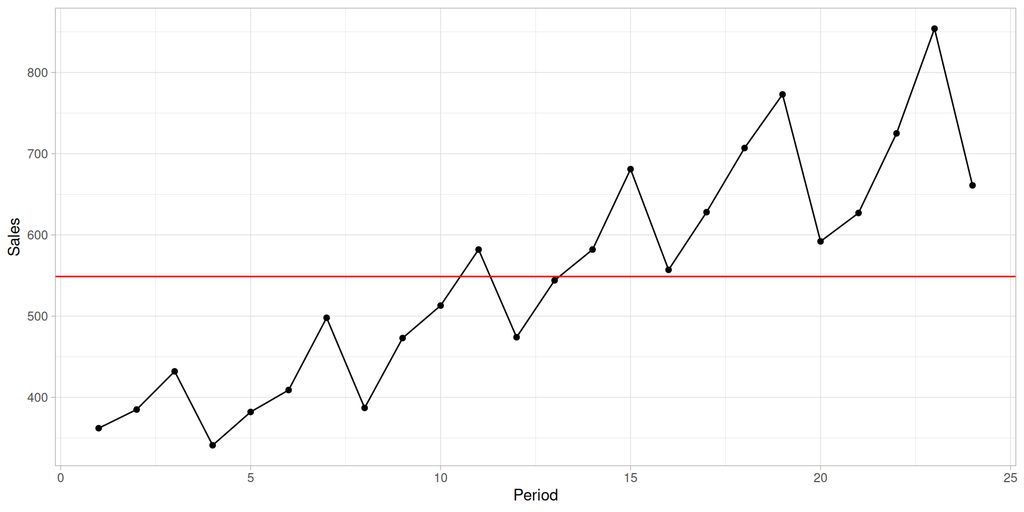

```r
quarterly_sales |>
  ggplot(aes(x = Period, y = Sales)) +
  geom_line() +
  geom_point() +
  geom_hline(yintercept = mean(quarterly_sales$Sales), color = "red") +
  theme_light()
```

## Moving Averages (7/8)

```r
quarterly_sales_moving_avg <- quarterly_sales |>
  mutate(
    moving_avg_3 = slider::slide_dbl(Sales, mean, .before = 1, .after = 1, .complete = TRUE),
    moving_avg_5 = slider::slide_dbl(Sales, mean, .before = 2, .after = 2, .complete = TRUE),
    moving_avg_7 = slider::slide_dbl(Sales, mean, .before = 3, .after = 3, .complete = TRUE)
  )

quarterly_sales_moving_avg
```

| Year | Quarter | Period | Sales | moving_avg_3 | moving_avg_5 | moving_avg_7 |
| --- | --- | --- | --- | --- | --- | --- |
| 90 | 1 | 1 | 362 | NA | NA | NA |
| 90 | 2 | 2 | 385 | 393.0000 | NA | NA |
| 90 | 3 | 3 | 432 | 386.0000 | 380.4 | NA |
| 90 | 4 | 4 | 341 | 385.0000 | 389.8 | 401.2857 |
| 91 | 1 | 5 | 382 | 377.3333 | 412.4 | 404.8571 |
| 91 | 2 | 6 | 409 | 429.6667 | 403.4 | 417.4286 |
| 91 | 3 | 7 | 498 | 431.3333 | 429.8 | 429.0000 |
| 91 | 4 | 8 | 387 | 452.6667 | 456.0 | 463.4286 |
| 92 | 1 | 9 | 473 | 457.6667 | 490.6 | 476.5714 |
| 92 | 2 | 10 | 513 | 522.6667 | 485.8 | 495.8571 |

[output cut: 14 more lines]

## Moving Averages (8/8)

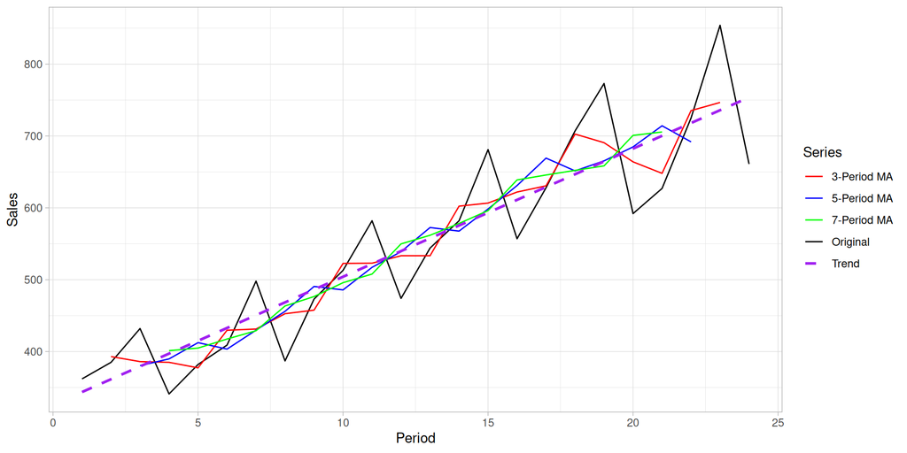

```r
quarterly_sales_moving_avg |>
  ggplot(aes(x = Period)) +
  geom_line(aes(y = Sales, color = "Original")) +
  geom_line(aes(y = moving_avg_3, color = "3-Period MA")) +
  geom_line(aes(y = moving_avg_5, color = "5-Period MA")) +
  geom_line(aes(y = moving_avg_7, color = "7-Period MA")) +
  geom_smooth(aes(y = Sales, color = "Trend"),
              method = "lm", formula = y ~ x,
              se = FALSE, linetype = "dashed") +
  scale_color_manual(values = c(
    "Original" = "black",
    "3-Period MA" = "red",
    "5-Period MA" = "blue",
    "7-Period MA" = "green",
    "Trend" = "purple"
  )) +
  labs(color = "Series") +  # Legend title
  theme_light()
```

# Analyzing Time Series Data: Exponential Smoothing

## Exponential Smoothing

- Single Exponential Smoothing
- Double Exponential Smoothing
- Triple Exponential Smoothing

## Single Exponential Smoothing

$$S_t = \alpha \sum_{i=1}^{t-2} (1-\alpha)^{i-1} y_{t-i}
+ (1-\alpha)^{t-2} y_1 \, , \,\,\,\,\, t \ge 2 \, .$$

$$\alpha \sum_{i=0}^{t-1} (1-\alpha)^i = \alpha \left[ \frac{1-(1-\alpha)^t}{1-(1-\alpha)} \right] = 1 - (1-\alpha)^t$$
$$S_t = \alpha y_{t-1} + (1-\alpha)S_{t-1} \,\,\,\,\,\,\, 0 < \alpha \le 1 \,\,\,\,\,\,\, t \ge 3$$

> We can see that the summation term shows that the contribution to the smoothed value becomes less at each consecutive time period.

> —6.4.3.1 Single Exponential Smoothing

## Single Exponential Smoothing Plot

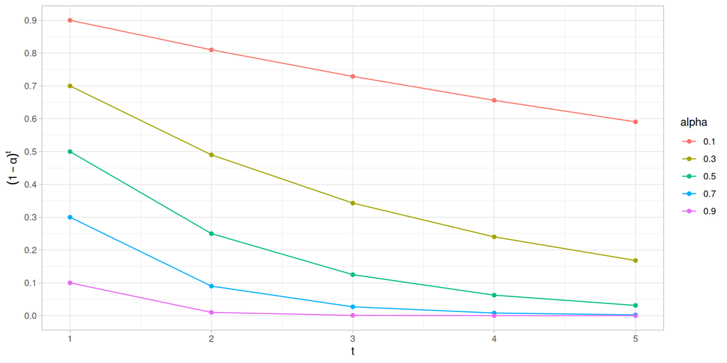

```r
# Plot of alpha (1 - alpha)^t for different values of alpha at t = 1:5
alpha_values <- c(0.1, 0.3, 0.5, 0.7, 0.9)
t_values <- 1:5

alpha_table <- tibble()

for (alpha in alpha_values) {
  alpha_table <- alpha_table |>
    bind_rows(
      tibble(
        alpha = alpha,
        t = t_values,
        value = (1 - alpha)^t
      )
    )
}

alpha_table |>
  ggplot(aes(x = t, y = value, color = factor(alpha))) +
  geom_point() +
  geom_line() +
  labs(
    x = "t",
    y = expression((1 - alpha)^t),
    color = "alpha"
  ) +
  scale_y_continuous(breaks = seq(0, 1, 0.1)) +
  theme_light()
```

## Simple Exponential Smoothing

$$S_t = \alpha x_t + (1 - \alpha) S_{t-1} \quad \text{for} \quad 0 \le \alpha \le 1$$

where $S_t$ is the smoothed value at time $t$, $x_t$ is the observed value at time $t$, and $\alpha$ is the smoothing parameter.

## Double Exponential Smoothing (Holt linear)

$$S_t = \alpha x_t + (1 - \alpha) (S_{t-1} + b_{t-1})$$

$$b_t = \beta (S_t - S_{t-1}) + (1 - \beta) b_{t-1}$$

where $b_t$ is the trend component at time $t$, and $\beta$ is the trend smoothing parameter.

## Triple Exponential Smoothing (Holt-Winters)

$$\begin{align}
S_t &= \alpha \frac{x_t}{c_t - L} + (1 - \alpha) (S_{t-1} + b_{t-1}) \\
b_t &= \beta (S_t - S_{t-1}) + (1 - \beta) b_{t-1} \\
c_t &= \gamma \frac{x_t}{S_t} + (1 - \gamma) c_{t-L}
\end{align}$$

Where $L$ is the length of the seasonal cycle, $c_t$ is the seasonal component at time $t$, and $\gamma$ is the seasonal smoothing parameter.

## Data from NIST (6.4.3.2)

Fit below was using a single exponential smoothing model with alpha = 0.3

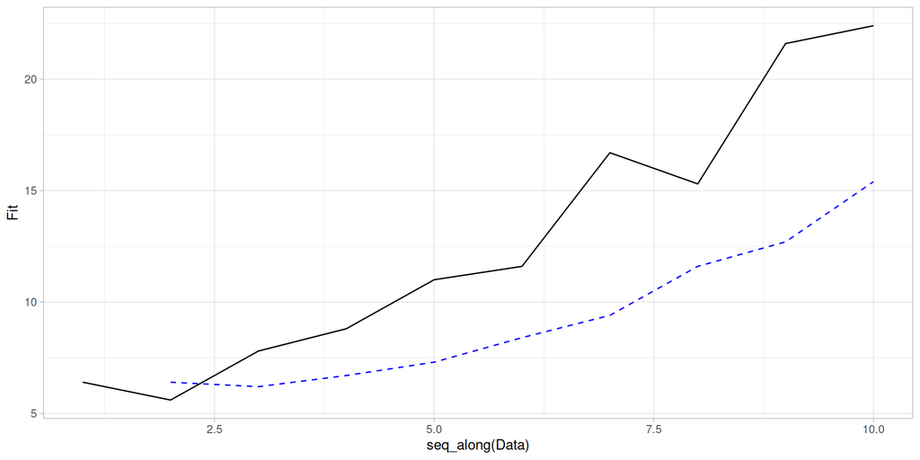

```r
sample_data <- read_table(
  "Data     Fit
6.4      NA
5.6     6.4
7.8     6.2
8.8     6.7
11.0    7.3
11.6    8.4
16.7    9.4
15.3    11.6
21.6    12.7
22.4    15.4", col_names = TRUE
)

sample_data |>
  ggplot() +
  geom_line(aes(x = seq_along(Data), y = Fit), color = "blue", linetype = "dashed") +
  geom_line(aes(x = seq_along(Data), y = Data), color = "black") +
  theme_light()
```

## Reproducing the fit

### Function for Single Exponential Smoothing

```r
ses_rjh <- function(x, alpha = 0.3) {
  n <- length(x)
  S_t <- numeric(n)  # Initialize vector with zeros

  # Set first value
  S_t[1] <- x[1]

  # Calculate smoothed values
  for(t in 2:n) {
    S_t[t] <- alpha * x[t] + (1 - alpha) * S_t[t-1]
  }

  return(S_t)
}
```

### Test the function

```r
ses_rjh(sample_data$Data, alpha = 0.3)
```

```
 [1]  6.400000  6.160000  6.652000  7.296400  8.407480  9.365236 11.565665
 [8] 12.685966 15.360176 17.472123
```

## Plot the SES fit

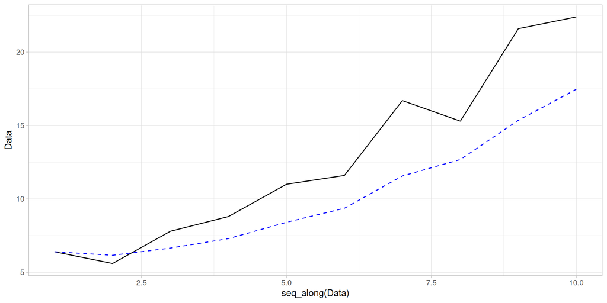

```r
sample_data |>
  mutate(fit2 = ses_rjh(Data, alpha = 0.3))  |>
  ggplot(aes(x = seq_along(Data))) +
  geom_line(aes(y = Data), color = "black") +
  # geom_line(aes(y = Fit), color = "red") +
  geom_line(aes(y = fit2), color = "blue", linetype = "dashed") +
  theme_light()
```

## Function for Double Exponential Smoothing

```r
des_rjh <- function(x, alpha = 0.3, beta = 0.3) {
  n <- length(x)
  S_t <- numeric(n)  # Initialize vector with zeros
  b_t <- numeric(n)  # Initialize vector with zeros

  # Set first value
  S_t[1] <- x[1]
  b_t[1] <- x[2] - x[1]

  # Calculate smoothed values
  for(t in 2:n) {
    S_t[t] <- alpha * x[t] + (1 - alpha) * (S_t[t-1] + b_t[t-1])
    b_t[t] <- beta * (S_t[t] - S_t[t-1]) + (1 - beta) * b_t[t-1]
  }

  return(S_t + b_t)
}
```

### Test the function

```r
des_rjh(sample_data$Data, alpha = 0.3, beta = 0.3)
```

```
 [1]  5.600000  4.800000  5.170000  6.055700  7.780677  9.511900 12.900685
 [8] 15.068773 19.064245 22.401293
```

## Plot the DES fit

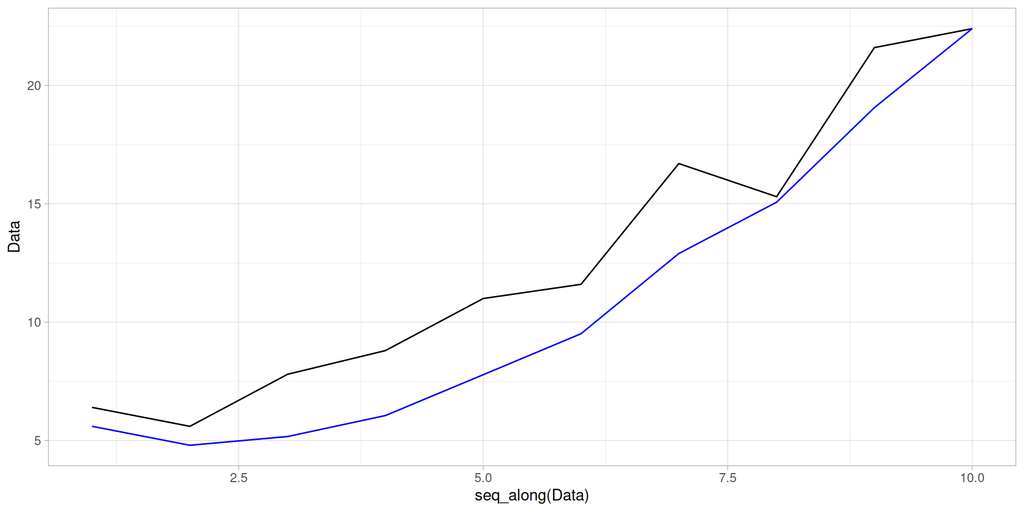

```r
sample_data |>
  mutate(fit2 = des_rjh(Data, alpha = 0.3, beta = 0.3))  |>
  ggplot(aes(x = seq_along(Data))) +
  geom_line(aes(y = Data), color = "black") +
  # geom_line(aes(y = Fit), color = "red") +
  geom_line(aes(y = fit2), color = "blue") +
  theme_light()
```

## Function for Triple Exponential Smoothing

```r
tes_rjh <- function(x, alpha = 0.3, b = 0.3, gamma = 0.3, m = 1) {
  n <- length(x)
  S_t <- numeric(n)  # Initialize vector with zeros
  b_t <- numeric(n)  # Initialize vector with zeros
  c_t <- numeric(n)  # Initialize vector with zeros

  # Set first value
  S_t[1] <- x[1]
  b_t[1] <- x[2] - x[1]
  c_t[1] <- x[3] - x[2]

  # Calculate smoothed values
  for(t in 2:n) {
    S_t[t] <- alpha * x[t] + (1 - alpha) * (S_t[t-1] + b_t[t-1])
    b_t[t] <- b * (S_t[t] - S_t[t-1]) + (1 - b) * b_t[t-1]
    c_t[t] <- gamma * (S_t[t] - S_t[t-1]) + (1 - gamma) * c_t[t-1]
  }

  return(S_t + b_t + c_t)
}
```

### Test the function

```r
tes_rjh(sample_data$Data, alpha = 0.3, b = 0.3, gamma = 0.3)
```

```
 [1]  7.800000  6.100000  6.110000  6.881400  8.742664 10.601536 14.485987
 [8] 16.764129 21.273293 24.858676
```

## Plot the fit TES fit

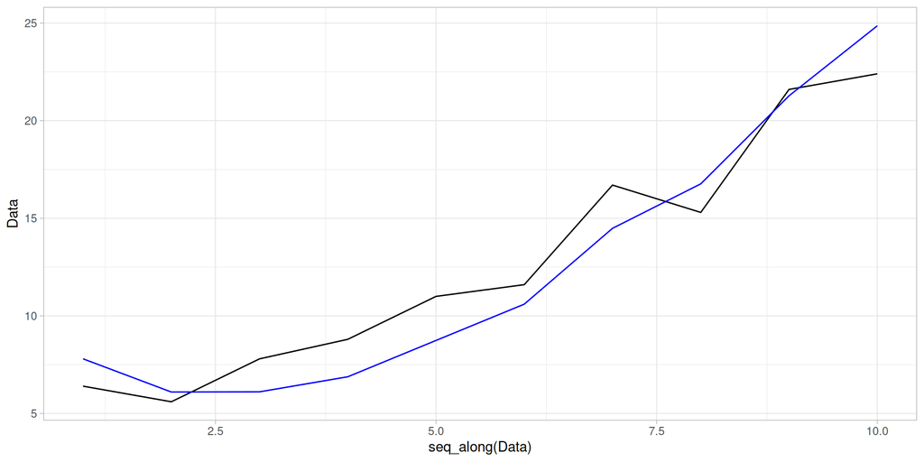

```r
sample_data |>
  mutate(fit2 = tes_rjh(Data, alpha = 0.3, b = 0.3, gamma = 0.3))  |>
  ggplot(aes(x = seq_along(Data))) +
  geom_line(aes(y = Data), color = "black") +
  # geom_line(aes(y = Fit), color = "red") +
  geom_line(aes(y = fit2), color = "blue") +
  theme_light()
```

## Seasonal Data

```r
quarterly_sales <- read_table(
  "Year     Quarter     Period     Sales
90     1      1     362
90     2      2     385
90     3      3     432
90     4      4     341
91     1      5     382
91     2      6     409
91     3      7     498
91     4      8     387
92     1      9     473
92     2     10     513
92     3     11     582
92     4     12     474
93     1     13     544
93     2     14     582
93     3     15     681
93     4     16     557
94     1     17     628
94     2     18     707
94     3     19     773
94     4     20     592
95     1     21     627
95     2     22     725
95     3     23     854
95     4     24     661", col_names = TRUE
)

quarterly_sales
```

| Year | Quarter | Period | Sales |
| --- | --- | --- | --- |
| 90 | 1 | 1 | 362 |
| 90 | 2 | 2 | 385 |
| 90 | 3 | 3 | 432 |
| 90 | 4 | 4 | 341 |
| 91 | 1 | 5 | 382 |
| 91 | 2 | 6 | 409 |
| 91 | 3 | 7 | 498 |
| 91 | 4 | 8 | 387 |
| 92 | 1 | 9 | 473 |
| 92 | 2 | 10 | 513 |

[output cut: 14 more lines]

## Use the tes_rjh function to “fit” the data “by eye”

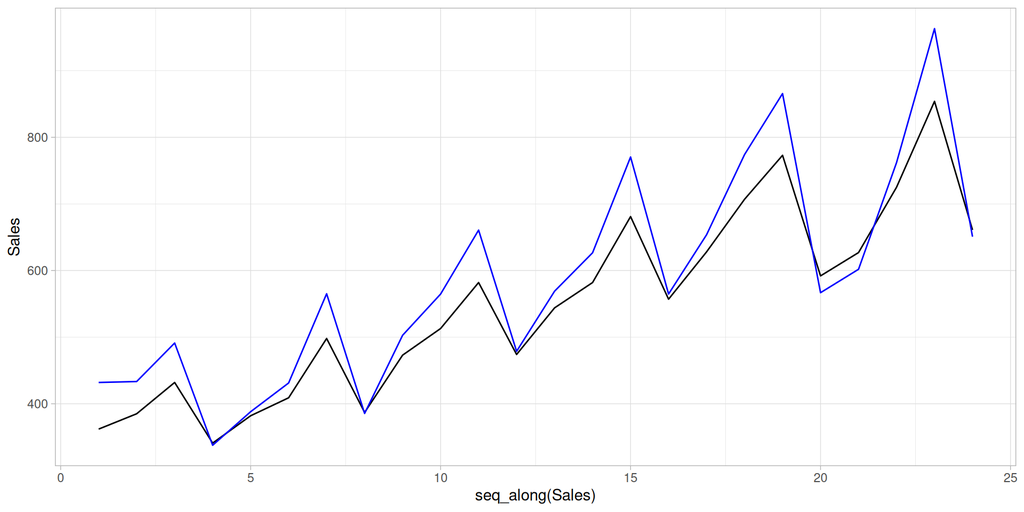

```r
quarterly_sales |>
  mutate(fit2 = tes_rjh(Sales, alpha = 0.7, b = 0.3, gamma = 0.9))  |>
  ggplot(aes(x = seq_along(Sales))) +
  geom_line(aes(y = Sales), color = "black") +
  geom_line(aes(y = fit2), color = "blue") +
  theme_light()
```

# Forecasting

## Convert the quarterly data to a tsibble (1/3)

```r
quarterly_sales_ts_simple <- quarterly_sales |>
  select(Sales) |>
  ts(start = c(1990, 1), frequency = 4) |>
  as_tsibble()

quarterly_sales_ts_simple
```

| index | value |
| --- | --- |
| 1990 Q1 | 362 |
| 1990 Q2 | 385 |
| 1990 Q3 | 432 |
| 1990 Q4 | 341 |
| 1991 Q1 | 382 |
| 1991 Q2 | 409 |
| 1991 Q3 | 498 |
| 1991 Q4 | 387 |
| 1992 Q1 | 473 |
| 1992 Q2 | 513 |

[output cut: 14 more lines]

## Convert the quarterly data to a tsibble (2/3)

```r
## Multivariate
z <- ts(matrix(rnorm(300), 100, 3), start = c(1961, 1), frequency = 12)
head(z)
```

```
            Series 1   Series 2    Series 3
Jan 1961 -0.07390786 -0.7541113 -1.36426407
Feb 1961  1.07346142 -0.4581309  0.06689076
Mar 1961 -0.12973053 -0.5335759 -0.86471178
Apr 1961 -1.16225597 -0.8301236  1.05508769
May 1961 -1.59357353  0.7092897  1.04144873
Jun 1961 -0.40684914  0.2400236 -1.91712477
```

## Convert the quarterly data to a tsibble (3/3)

```r
tbl3 <- tibble(
  mth = rep(yearmonth("2010 Jan") + 0:8, each = 3),
  xyz = rep(c("x", "y", "z"), each = 9),
  abc = rep(letters[1:3], times = 9),
  value = rnorm(27)
)
as_tsibble(tbl3, key = c(xyz, abc))
```

| mth | xyz | abc | value |
| --- | --- | --- | --- |
| 2010 Jan | x | a | -0.8194899 |
| 2010 Feb | x | a | 0.7873322 |
| 2010 Mar | x | a | 0.8435618 |
| 2010 Jan | x | b | 0.7022298 |
| 2010 Feb | x | b | 0.3218267 |
| 2010 Mar | x | b | -0.3076803 |
| 2010 Jan | x | c | 0.4910745 |
| 2010 Feb | x | c | -0.3909991 |
| 2010 Mar | x | c | -0.3380656 |
| 2010 Apr | y | a | 0.7490470 |

[output cut: 17 more lines]

## Use the ETS function from fpp3 (1/3)

```r
quarterly_sales
```

| Year | Quarter | Period | Sales |
| --- | --- | --- | --- |
| 90 | 1 | 1 | 362 |
| 90 | 2 | 2 | 385 |
| 90 | 3 | 3 | 432 |
| 90 | 4 | 4 | 341 |
| 91 | 1 | 5 | 382 |
| 91 | 2 | 6 | 409 |
| 91 | 3 | 7 | 498 |
| 91 | 4 | 8 | 387 |
| 92 | 1 | 9 | 473 |
| 92 | 2 | 10 | 513 |

[output cut: 14 more lines]

## Use the ETS function from fpp3 (2/3)

```r
quarterly_sales_tsibble <- quarterly_sales |>
  mutate(
    # Convert 2-digit year to 4-digit year
    Year = 1900 + Year,
    # Create proper quarter dates by converting to months (Q1=1, Q2=4, Q3=7, Q4=10)
    Month = (Quarter - 1) * 3 + 1,
    # Create the yearquarter date
    YearQuarter = yearquarter(paste(Year, Month, "01", sep = "-"))
  ) |>
  # Select needed columns and convert to tsibble
  select(YearQuarter, Sales) |>
  as_tsibble(
    index = YearQuarter
  )

quarterly_sales_tsibble
```

| YearQuarter | Sales |
| --- | --- |
| 1990 Q1 | 362 |
| 1990 Q2 | 385 |
| 1990 Q3 | 432 |
| 1990 Q4 | 341 |
| 1991 Q1 | 382 |
| 1991 Q2 | 409 |
| 1991 Q3 | 498 |
| 1991 Q4 | 387 |
| 1992 Q1 | 473 |
| 1992 Q2 | 513 |

[output cut: 14 more lines]

## An easier way to get the data frame

```r
quarterly_sales_tsibble2 <- quarterly_sales |>
 select(Sales) |>
  ts(start = c(1990, 1), frequency = 4) |>
  as_tsibble()

quarterly_sales_tsibble2
```

| index | value |
| --- | --- |
| 1990 Q1 | 362 |
| 1990 Q2 | 385 |
| 1990 Q3 | 432 |
| 1990 Q4 | 341 |
| 1991 Q1 | 382 |
| 1991 Q2 | 409 |
| 1991 Q3 | 498 |
| 1991 Q4 | 387 |
| 1992 Q1 | 473 |
| 1992 Q2 | 513 |

[output cut: 14 more lines]

## Use the ETS function from fpp3 (3/3)

```r
fit_ets <- quarterly_sales_tsibble |>
  model(model_ets = ETS(Sales ~ error("A") + trend("A") + season("A")))

autoplot(quarterly_sales_tsibble, Sales) +
  geom_line(aes(y = .fitted), data = augment(fit_ets), color = "blue")
```

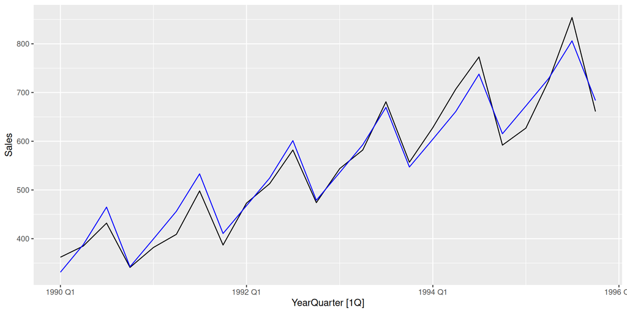

## Forecasting with ETS

```r
fit_ets |>
  forecast(h = 8) |>
  autoplot(quarterly_sales_tsibble)
```

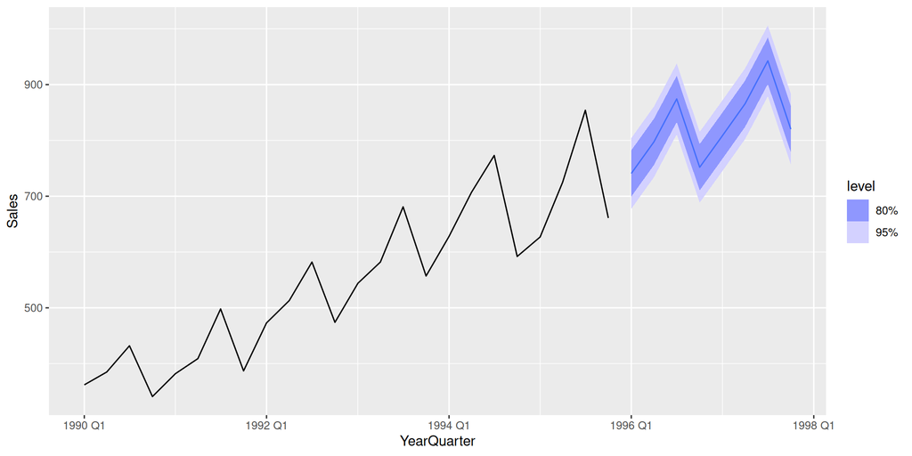

## Fit and Forecasat with ETS

```r
fit_ets |>
  forecast(h = 8) |>
  autoplot(quarterly_sales_tsibble) +
  geom_line(aes(y = .fitted), data = augment(fit_ets), color = "blue")
```

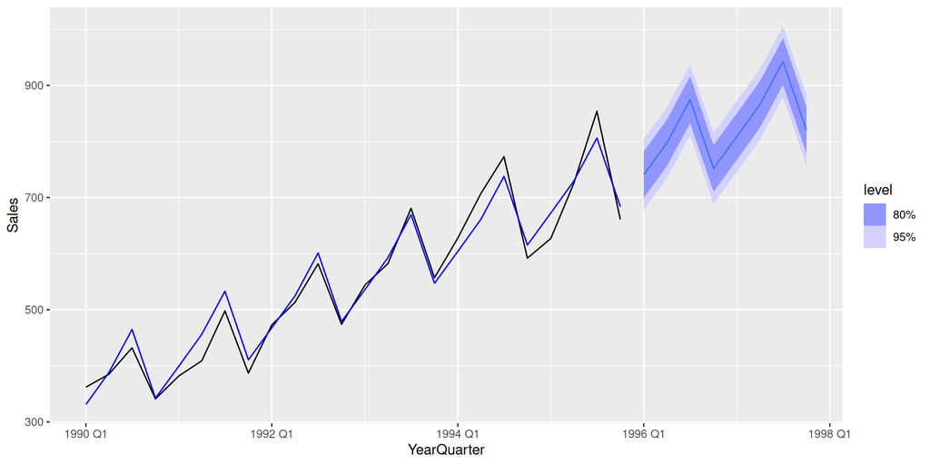

# In Practice

## Real World Example: SEMI Forecasting

[Global Silicon Wafer Shipments](https://www.semi.org/en/news-media-press-releases/semi-press-releases/global-silicon-wafer-shipments-to-remain-soft-in-2024-before-strong-expected-rebound-in-2025-SEMI-reports)

Units are in “million square inches (MSI)”

```r
msi_historical <- read_tsv("datasets/MSI.txt", col_names = c("year", "Q1", "Q2", "Q3", "Q4"))
msi_historical
```

| year | Q1 | Q2 | Q3 | Q4 |
| --- | --- | --- | --- | --- |
| 2000 | Q1 1,274 | Q2 1,373 | Q3 1,457 | Q4 1,448 |
| 2001 | Q1 1,250 | Q2 988 | Q3 824 | Q4 878 |
| 2002 | Q1 1,011 | Q2 1,273 | Q3 1,263 | Q4 1,134 |
| 2003 | Q1 1,175 | Q2 1,273 | Q3 1,307 | Q4 1,392 |
| 2004 | Q1 1,529 | Q2 1,619 | Q3 1,629 | Q4 1,486 |
| 2005 | Q1 1,465 | Q2 1,606 | Q3 1,748 | Q4 1,826 |
| 2006 | Q1 1,884 | Q2 1,966 | Q3 2,074 | Q4 2,070 |
| 2007 | Q1 2,100 | Q2 2,201 | Q3 2,174 | Q4 2,185 |
| 2008 | Q1 2,163 | Q2 2,303 | Q3 2,243 | Q4 1,428 |
| 2009 | Q1 940 | Q2 1,686 | Q3 1,972 | Q4 2,109 |

[output cut: 15 more lines]

## Wrangle the Data into a Long Format

| year | quarter | msi |
| --- | --- | --- |
| 2001 | Q1 | 1250 |
| 2001 | Q2 | 988 |
| … | … | … |

### And convert to a time series object (tsibble)

```r
msi_ts <- msi_historical |>
  pivot_longer(cols = -year, names_to = "quarter", values_to = "quarter_value", ) |>
  separate_wider_delim(cols = quarter_value, names = c("quarter_2", "msi"), delim = " ") |>
  mutate(msi = as.numeric(str_remove(msi, ","))) |>
  select(-quarter_2) |>
  mutate(year_quarter = str_c(year, " ", quarter)) |>
  select(year_quarter, msi) |>
  mutate(year_quarter = yearquarter(year_quarter)) |>
  filter(!is.na(msi)) |>
  as_tsibble(index = year_quarter)

msi_ts
```

| year_quarter | msi |
| --- | --- |
| 2000 Q1 | 1274 |
| 2000 Q2 | 1373 |
| 2000 Q3 | 1457 |
| 2000 Q4 | 1448 |
| 2001 Q1 | 1250 |
| 2001 Q2 | 988 |
| 2001 Q3 | 824 |
| 2001 Q4 | 878 |
| 2002 Q1 | 1011 |
| 2002 Q2 | 1273 |

[output cut: 88 more lines]

## Plot the Time Series

```r
my_theme <- theme(
    plot.title = ggtext::element_markdown(size = 18, face = "bold"),
    plot.title.position = "plot",
    plot.subtitle = ggtext::element_markdown(size = 14),
    axis.text.x = ggtext::element_markdown(size = 14),
    axis.text.y = ggtext::element_markdown(size = 14),
    plot.caption = ggtext::element_markdown(hjust = 0, margin = margin(t = 20)),
    plot.caption.position = "plot"
    )

msi_ts |>
  autoplot(msi) +
  labs(
    x = NULL,
    y = NULL,
    title = "Global Silicon Wafer Shipments",
    subtitle = "MSI (million square inches)",
    caption = "Source: SEMI, October 2024"
  ) +
  scale_y_continuous(labels = scales::comma) +
  scale_x_yearquarter(date_labels = "%Y", date_minor_breaks = "1 year") +
  theme_light() +
  my_theme
```

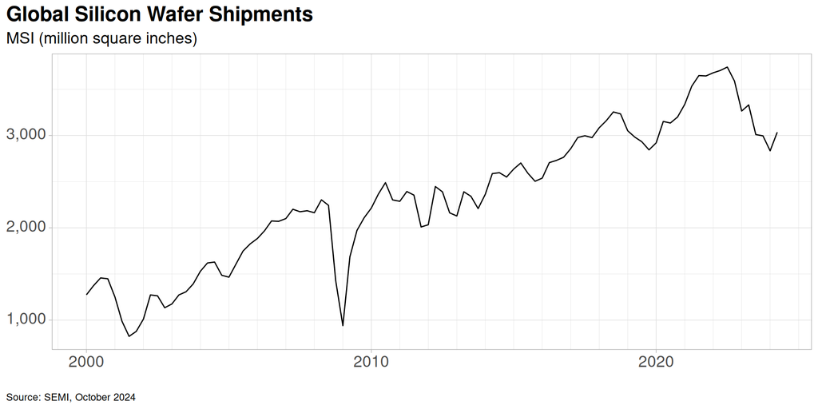

## Fit and Forecast with ETS

```r
fit_ets_msi <- msi_ts |>
  model(model_ets = ETS(msi ~ error("A") + trend("A") + season("A")))

fit_ets_msi |>
  forecast(h = 12) |>
  autoplot(msi_ts) +
  geom_line(aes(y = .fitted), data = augment(fit_ets_msi), color = "blue") +
  labs(
    x = NULL,
    y = NULL,
    title = "Global Silicon Wafer Shipments",
    subtitle = "MSI (million square inches)",
    caption = "Source: SEMI, October 2024"
  ) +
  scale_y_continuous(labels = scales::comma) +
  scale_x_yearquarter(date_labels = "%Y", date_minor_breaks = "1 year") +
  theme_light() +
  my_theme
```

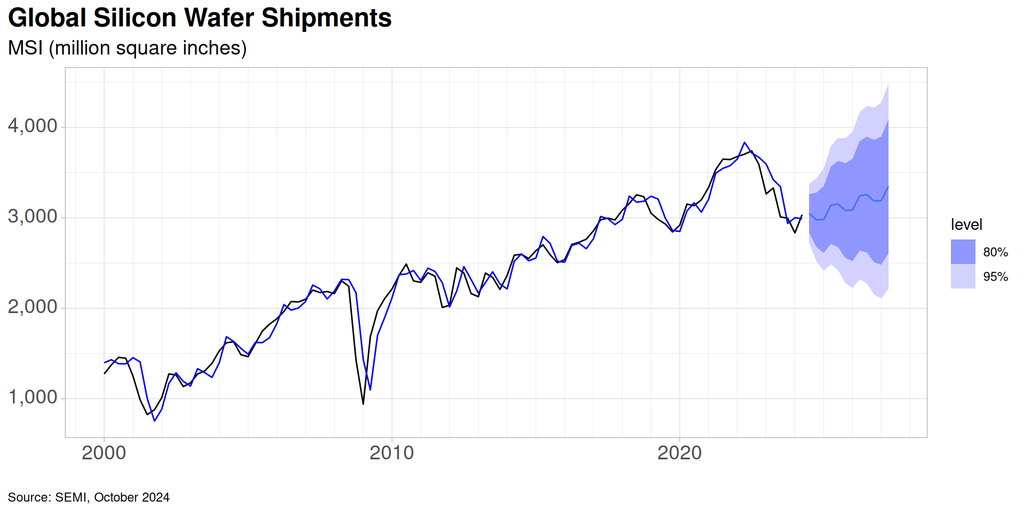

## Forecasted Values using ARIMA

```r
fit_arima_msi <- msi_ts |>
  model(model_arima = ARIMA(msi, stepwise = FALSE, approximation = FALSE))

fit_arima_msi |>
  forecast(h = 12) |>
  autoplot(msi_ts) +
  geom_line(aes(y = .fitted), data = augment(fit_arima_msi), color = "blue") +
  labs(
    x = NULL,
    y = NULL,
    title = "Global Silicon Wafer Shipments",
    subtitle = "MSI (million square inches)",
    caption = "Source: SEMI, October 2024"
  ) +
  scale_y_continuous(labels = scales::comma) +
  scale_x_yearquarter(date_labels = "%Y", date_minor_breaks = "1 year") +
  theme_light() +
  my_theme
```

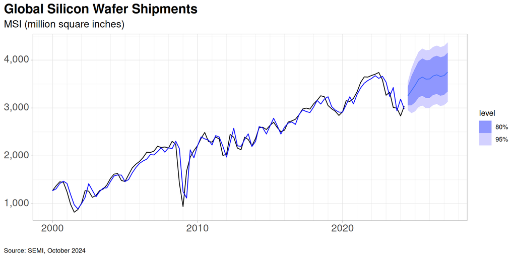

## Forecasted Values by Year

```r
msi_three_year_forecast <- fit_arima_msi |>
  forecast(h = 14)

msi_three_year_forecast_annual <- as_tibble(msi_three_year_forecast) |>
  mutate(year = year(year_quarter)) |>
  group_by(year) |>
  summarise(
    forecasted_msi = sum(.mean))

msi_three_year_forecast_annual
```

| year | forecasted_msi |
| --- | --- |
| 2024 | 6611.48 |
| 2025 | 14319.19 |
| 2026 | 14623.01 |
| 2027 | 14962.60 |

```r
msi_long_year <- msi_historical |>
  pivot_longer(cols = -year, names_to = "quarter", values_to = "quarter_value", ) |>
  separate_wider_delim(cols = quarter_value, names = c("quarter_2", "msi"), delim = " ") |>
  mutate(msi = as.numeric(str_remove(msi, ","))) |>
  select(-quarter_2) |>
  group_by(year) |>
  summarise(
    msi = sum(msi, na.rm = TRUE)
  ) |>
  ungroup()

msi_long_year
```

| year | msi |
| --- | --- |
| 2000 | 5552 |
| 2001 | 3940 |
| 2002 | 4681 |
| 2003 | 5147 |
| 2004 | 6263 |
| 2005 | 6645 |
| 2006 | 7994 |
| 2007 | 8660 |
| 2008 | 8137 |
| 2009 | 6707 |

[output cut: 15 more lines]

## Join the Data Frames

```r
msi_long_year_join <- msi_long_year |>
  full_join(msi_three_year_forecast_annual, by = "year") |>
  pivot_longer(cols = c(msi, forecasted_msi), names_to = "type", values_to = "msi")

msi_long_year_join
```

| year | type | msi |
| --- | --- | --- |
| 2000 | msi | 5552.00 |
| 2000 | forecasted_msi | NA |
| 2001 | msi | 3940.00 |
| 2001 | forecasted_msi | NA |
| 2002 | msi | 4681.00 |
| 2002 | forecasted_msi | NA |
| 2003 | msi | 5147.00 |
| 2003 | forecasted_msi | NA |
| 2004 | msi | 6263.00 |
| 2004 | forecasted_msi | NA |

[output cut: 46 more lines]

## SEMI Forecast

```r
semi_forecast <- tibble(
  year = 2024:2027,
  semi_foreast_msi = c(12174, 13328, 14507, 15413)
)

semi_forecast
```

| year | semi_foreast_msi |
| --- | --- |
| 2024 | 12174 |
| 2025 | 13328 |
| 2026 | 14507 |
| 2027 | 15413 |

## ARIMA Forecast

```r
arima_forecast <- msi_long_year_join |>
  filter(year >= 2024) |>
  group_by(year) |>
  summarise(
    msi = sum(msi, na.rm = TRUE)
  ) |>
  ungroup()

arima_forecast
```

| year | msi |
| --- | --- |
| 2024 | 12480.48 |
| 2025 | 14319.19 |
| 2026 | 14623.01 |
| 2027 | 14962.60 |

## Plot the ARIMA vs SEMI Forecast

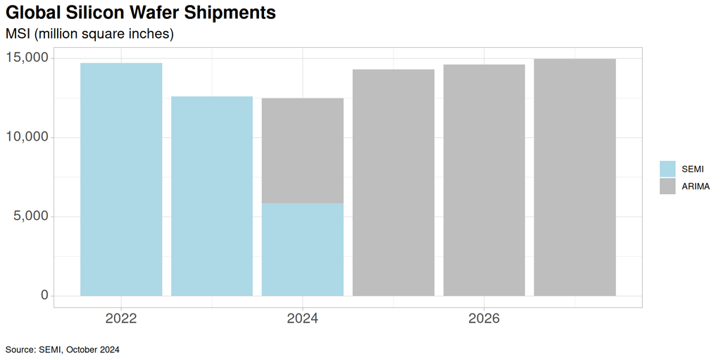

```r
msi_long_year_join |>
  filter(year >= 2022) |>
  ggplot(aes(x = year)) +
  geom_col(aes(y = msi, fill = type)) +
  labs(
    x = NULL,
    y = NULL,
    title = "Global Silicon Wafer Shipments",
    subtitle = "MSI (million square inches)",
    caption = "Source: SEMI, October 2024",
  ) +
  scale_y_continuous(labels = scales::comma) +
  scale_fill_manual(values = c("grey", "lightblue"), name = NULL, labels = c("ARIMA", "SEMI")) +
  guides(fill = guide_legend(reverse = TRUE)) +
  theme_light() +
  my_theme
```

## Plot the ARIMA vs SEMI Forecast (with SEMI Forecast)

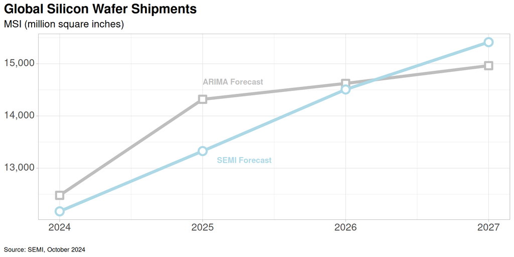

```r
ggplot() +
  geom_line(aes(x = year, y = msi), data = arima_forecast, color = "grey", linewidth = 2) +
  geom_line(aes(x = year, y = semi_foreast_msi), data = semi_forecast, color = "lightblue", linewidth = 2) +
  geom_point(aes(x = year, y = msi),
             data = arima_forecast, color = "grey", shape = 22, size = 4, stroke = 2, fill = "white") +
  geom_point(aes(x = year, y = semi_foreast_msi),
             data = semi_forecast, color = "lightblue", shape = 21, size = 4, stroke = 2, fill = "white") +
  annotate("text", x = 2025, y = 14600, label = "ARIMA Forecast", hjust = 0, vjust = 0,
           color = "grey", fontface = "bold") +
  annotate("text", x = 2025.1, y = 13100, label = "SEMI Forecast", hjust = 0, vjust = 0,
           color = "lightblue", fontface = "bold") +
  scale_y_continuous(labels = scales::comma) +
  labs(
    x = NULL,
    y = NULL,
    title = "Global Silicon Wafer Shipments",
    subtitle = "MSI (million square inches)",
    caption = "Source: SEMI, October 2024",
  ) +
  theme_light() +
  my_theme
```

# Homework

## Univariate Time Series Carbon Dioxide Data

### Monthly $\textrm{CO}_2$ Concentrations

```r
co2
```

```
        Jan    Feb    Mar    Apr    May    Jun    Jul    Aug    Sep    Oct
1959 315.42 316.31 316.50 317.56 318.13 318.00 316.39 314.65 313.68 313.18
1960 316.27 316.81 317.42 318.87 319.87 319.43 318.01 315.74 314.00 313.68
1961 316.73 317.54 318.38 319.31 320.42 319.61 318.42 316.63 314.83 315.16
1962 317.78 318.40 319.53 320.42 320.85 320.45 319.45 317.25 316.11 315.27
1963 318.58 318.92 319.70 321.22 322.08 321.31 319.58 317.61 316.05 315.83
1964 319.41 320.07 320.74 321.40 322.06 321.73 320.27 318.54 316.54 316.71
1965 319.27 320.28 320.73 321.97 322.00 321.71 321.05 318.71 317.66 317.14
1966 320.46 321.43 322.23 323.54 323.91 323.59 322.24 320.20 318.48 317.94
1967 322.17 322.34 322.88 324.25 324.83 323.93 322.38 320.76 319.10 319.24
1968 322.40 322.99 323.73 324.86 325.40 325.20 323.98 321.95 320.18 320.09
1969 323.83 324.26 325.47 326.50 327.21 326.54 325.72 323.50 322.22 321.62
1970 324.89 325.82 326.77 327.97 327.91 327.50 326.18 324.53 322.93 322.90
1971 326.01 326.51 327.01 327.62 328.76 328.40 327.20 325.27 323.20 323.40
1972 326.60 327.47 327.58 329.56 329.90 328.92 327.88 326.16 324.68 325.04
```

[output cut: 65 more lines]

## Fit an ETS Model to the `co2` data (1/5)

### Convert to a `tsibble`

```r
co2_tsibble <- co2 |>
  as_tsibble(index = yearmonth)

co2_tsibble
```

| index | value |
| --- | --- |
| 1959 Jan | 315.42 |
| 1959 Feb | 316.31 |
| 1959 Mar | 316.50 |
| 1959 Apr | 317.56 |
| 1959 May | 318.13 |
| 1959 Jun | 318.00 |
| 1959 Jul | 316.39 |
| 1959 Aug | 314.65 |
| 1959 Sep | 313.68 |
| 1959 Oct | 313.18 |

[output cut: 458 more lines]

## Fit an ETS Model to the `co2` data (2/5)

### Fit the ETS model

```r
fit_ets_co2 <- co2_tsibble |>
  model(model_ets = ETS(value ~ error("A") + trend("A") + season("A")))
```

## Fit an ETS Model to the `co2` data (3/5)

### Forecast and plot

```r
fit_ets_co2 |>
  forecast(h = 324) |>
  autoplot(co2_tsibble) +
  geom_point(x = as_date("2024-10-01"), y = 422, color = "red", size = 4) +
  theme_light()
```

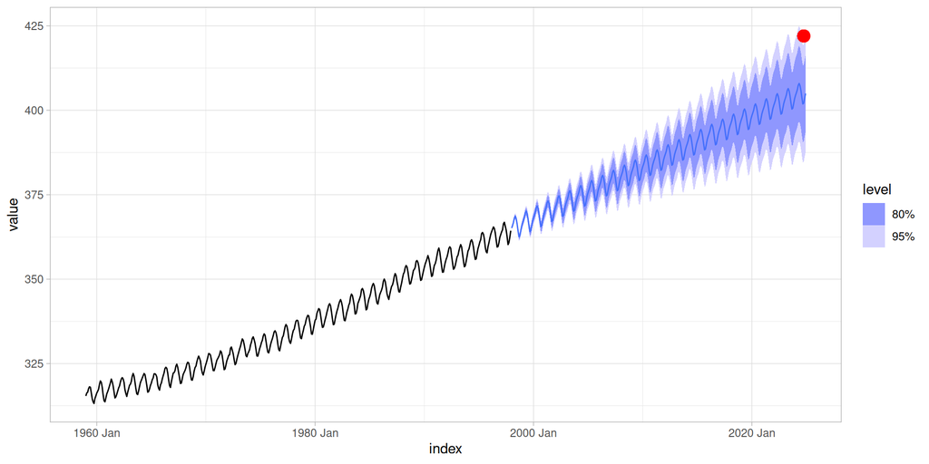

## Fit an ETS Model to the `co2` data (4/5)

### Plot the data, fit, and forecast

```r
co2_column_names <- c("year", "month", "decimal_date", "monthly_average", "deseasonalized", "n_days", "stdev_days", "uncertainty_mean")

co2_current_data <- read_table("https://gml.noaa.gov/webdata/ccgg/trends/co2/co2_mm_mlo.txt", skip = 52, col_names = co2_column_names)

co2_current_data
```

| year | month | decimal_date | monthly_average | deseasonalized | n_days | stdev_days | uncertainty_mean |
| --- | --- | --- | --- | --- | --- | --- | --- |
| 1959 | 1 | 1959.041 | 315.58 | 315.52 | -1 | -9.99 | -0.99 |
| 1959 | 2 | 1959.126 | 316.49 | 315.84 | -1 | -9.99 | -0.99 |
| 1959 | 3 | 1959.203 | 316.65 | 315.37 | -1 | -9.99 | -0.99 |
| 1959 | 4 | 1959.288 | 317.72 | 315.42 | -1 | -9.99 | -0.99 |
| 1959 | 5 | 1959.370 | 318.29 | 315.46 | -1 | -9.99 | -0.99 |
| 1959 | 6 | 1959.455 | 318.15 | 316.00 | -1 | -9.99 | -0.99 |
| 1959 | 7 | 1959.537 | 316.54 | 315.87 | -1 | -9.99 | -0.99 |
| 1959 | 8 | 1959.622 | 314.80 | 316.09 | -1 | -9.99 | -0.99 |
| 1959 | 9 | 1959.707 | 313.84 | 316.75 | -1 | -9.99 | -0.99 |
| 1959 | 10 | 1959.789 | 313.33 | 316.34 | -1 | -9.99 | -0.99 |

[output cut: 799 more lines]

## Create a `ts` objectd

```r
co2_current_data_ts <- co2_current_data |>
  select(monthly_average) |>
  ts(start = c(1959, 1), frequency = 12) |>
  as_tsibble()

co2_current_data_ts
```

| index | value |
| --- | --- |
| 1959 Jan | 315.58 |
| 1959 Feb | 316.49 |
| 1959 Mar | 316.65 |
| 1959 Apr | 317.72 |
| 1959 May | 318.29 |
| 1959 Jun | 318.15 |
| 1959 Jul | 316.54 |
| 1959 Aug | 314.80 |
| 1959 Sep | 313.84 |
| 1959 Oct | 313.33 |

[output cut: 799 more lines]

## Fit an ETS Model to the `co2` data (5/5)

```r
fit_ets_co2_current <- co2_current_data_ts |>
  model(model_ets = ETS(value ~ error("A") + trend("A") + season("A")))

fit_ets_co2_current |>
       forecast(h = 120) |>
  autoplot(filter(co2_current_data_ts, index >= yearmonth("2000-01-1"))) +
  scale_x_yearmonth(date_labels = "%Y") +
  labs(
    x = "Year",
    y = "CO<sub>2</sub> Concentration (ppm)"
  ) +
  theme_light() +
  theme(axis.title.y = ggtext::element_markdown())
```

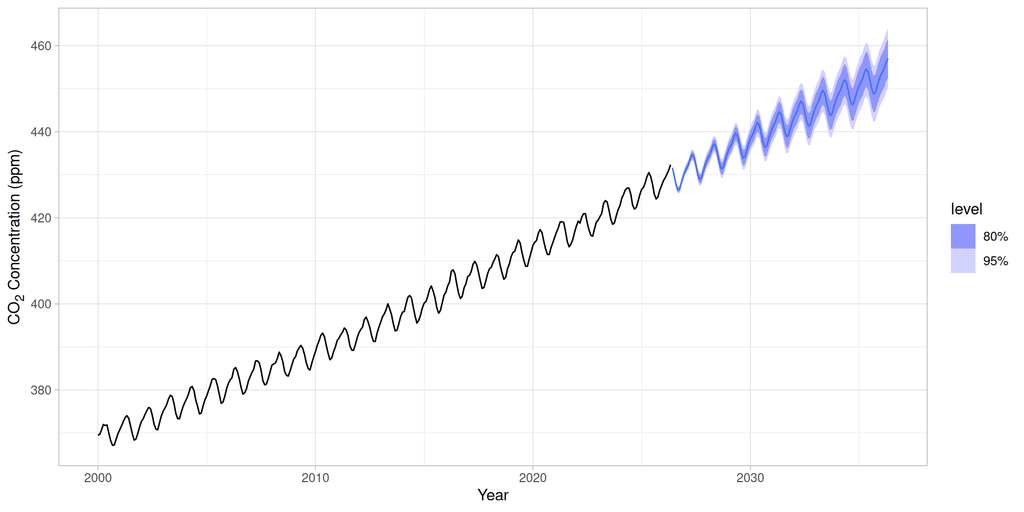